# LAB1

Grupo 4

2026-02-02

```r
movies<-read.csv("movies_2026.csv")
```

```r
library(dplyr)
```

```r
library(ggplot2)
library(tidyr)
library(nortest)
```

```r
movies <- movies %>%
  mutate(across(
    c(popularity, budget, revenue, genresAmount, productionCoAmount,
      productionCountriesAmount, voteCount, actorsAmount, castWomenAmount,
      castMenAmount, releaseYear, runtime, voteAvg, actorsPopularity),
    ~ as.numeric(.)
  ))
```

# Ejercicio 1 - Haga una exploración rápida de sus datos, para eso haga un resumen de su conjunto

#de datos.

```r
# Dimensiones del DataSet
dim(movies)
```

```
## [1] 19883    28
```

Para este primer ejercicio, utilizamos la función `dim()` para conocer el tamaño exacto de nuestra base de datos. Como podemos observar en el resultado del código, el dataset tiene 19,883 filas por 28 columnas. Esto significa que contamos con información de 19,883 películas diferentes y, para cada una de ellas, tenemos 28 variables o características (como el presupuesto, el género, los ingresos, etc.) para analizar.

# Ejercicio 2 - Diga el tipo de cada una de las variables (cualitativa ordinal o nominal, cuantitativa

#continua, cuantitativa discreta)

# Clasificación de Variables

[output not shown]

## Separar variables cualitativas y cuantitativas

### Lista de Variables Cualitativas (Nominales y Ordinales)

```r
movies_cualitativas <- c("id", "originalTitle", "originalLanguage", "title", "homePage",
                   "video", "director", "genres", "productionCompany",
                   "productionCompanyCountry", "productionCountry",
                   "actors", "actorsCharacter", "releaseDate")

movies_cuali <- movies[, movies_cualitativas]
```

### Lista de Variables Cuantitativas (Discretas y Continuas)

```r
movies_cuantitativas <- c("popularity", "budget", "revenue", "genresAmount",
                    "productionCoAmount", "productionCountriesAmount",
                    "voteCount", "actorsAmount", "castWomenAmount",
                    "castMenAmount", "releaseYear", "runtime",
                    "voteAvg", "actorsPopularity")

movies_cuanti <- movies[, movies_cuantitativas]
```

# Ejercicio 3 Investigue si las variables cuantitativas siguen una distribución normal y haga una

# tabla de frecuencias de las variables cualitativas. Explique todos los resultados.

```r
resultados_lillie <- data.frame(
  Variable = character(),
  P_value = numeric(),
  Normalidad = character()
)


for (var in movies_cuantitativas) {
  x <- na.omit(movies[[var]])

  # Saltar variables no numéricas reales (como fechas)
  if (!is.numeric(x)) next

  test <- nortest::lillie.test(x)


  resultados_lillie <- rbind(
    resultados_lillie,
    data.frame(
      Variable = var,
      P_value = test$p.value,
      Normalidad = ifelse(test$p.value > 0.05, "Sí", "No")
    )
  )
}

resultados_lillie
```

```
##                     Variable P_value Normalidad
## 1                 popularity       0         No
## 2                     budget       0         No
## 3                    revenue       0         No
## 4               genresAmount       0         No
## 5         productionCoAmount       0         No
## 6  productionCountriesAmount       0         No
## 7                  voteCount       0         No
## 8               actorsAmount       0         No
## 9            castWomenAmount       0         No
## 10             castMenAmount       0         No
## 11               releaseYear       0         No
## 12                   runtime       0         No
## 13                   voteAvg       0         No
## 14          actorsPopularity       0         No
```

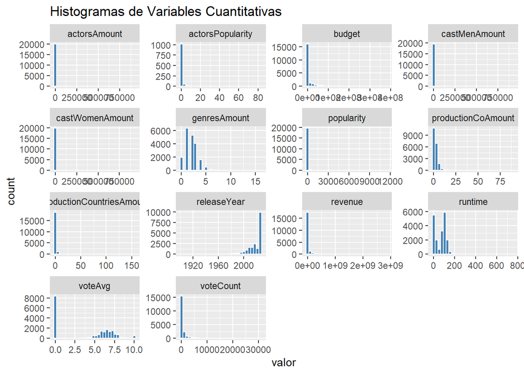

```r
movies |>
  select(all_of(movies_cuantitativas)) |>
  pivot_longer(cols = everything(),
               names_to = "variable",
               values_to = "valor") |>
  filter(!is.na(valor)) |>
  ggplot(aes(x = valor)) +
  geom_histogram(bins = 30, fill = "steelblue", color = "white") +
  facet_wrap(~variable, scales = "free") +
  labs(title = "Histogramas de Variables Cuantitativas")
```

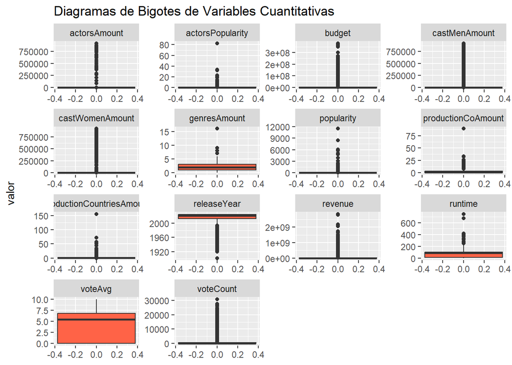

```r
movies |>
  select(all_of(movies_cuantitativas)) |>
  pivot_longer(cols = everything(),
               names_to = "variable",
               values_to = "valor") |>
  filter(!is.na(valor)) |>
  ggplot(aes(y = valor)) +
  geom_boxplot(fill = "tomato") +
  facet_wrap(~variable, scales = "free") +
  labs(title = "Diagramas de Bigotes de Variables Cuantitativas")
```

```r
# Idioma original
freq_idioma <- movies %>%
  count(originalLanguage, sort = TRUE)

# Video promocional
freq_video <- movies %>%
  count(video, sort = TRUE)

# Géneros
freq_generos <- movies %>%
  count(genres, sort = TRUE)

# País de producción
freq_pais <- movies %>%
  count(productionCountry, sort = TRUE)

# País de la productora
freq_pais_prod <- movies %>%
  count(productionCompanyCountry, sort = TRUE)

# Directores (Top 10)
freq_director <- movies %>%
  count(director, sort = TRUE) %>%
  head(10)

# Productoras (Top 10)
freq_productora <- movies %>%
  count(productionCompany, sort = TRUE) %>%
  head(10)

freq_idioma
```

```
##    originalLanguage     n
## 1                en 11961
## 2                es  1238
## 3                fr  1094
## 4                ja   868
## 5                pt   628
## 6                de   461
## 7                zh   365
## 8                ko   336
## 9                it   302
## 10               nl   192
## 11               ru   190
## 12               id   173
## 13               sv   133
## 14               tl   110
```

[output cut: 80 more lines]

```r
freq_video
```

```
##   video     n
## 1 FALSE 19313
## 2    NA   486
## 3  TRUE    84
```

```r
freq_generos
```

```
##                                                                            genres
## 1
## 2                                                                     Documentary
## 3                                                                           Drama
## 4                                                                          Comedy
## 5                                                                          Horror
## 6                                                                       Animation
## 7                                                                   Drama|Romance
## 8                                                                 Horror|Thriller
## 9                                                                    Comedy|Drama
## 10                                                                 Comedy|Romance
## 11                                                                       Thriller
## 12                                                                          Music
## 13                                                                   Drama|Comedy
## 14                                                                 Drama|Thriller
```

[output cut: 5643 more lines]

```r
freq_pais
```

```
##                                                                                                                                                   productionCountry
## 1                                                                                                                                          United States of America
## 2
## 3                                                                                                                                                                US
## 4                                                                                                                                                             Japan
## 5                                                                                                                                                                FR
## 6                                                                                                                                                                GB
## 7                                                                                                                           United Kingdom|United States of America
## 8                                                                                                                                                                BR
## 9                                                                                                                                                                IN
## 10                                                                                                                                                               DE
## 11                                                                                                                                                   United Kingdom
## 12                                                                                                                                  Canada|United States of America
## 13                                                                                                                                                               CA
## 14                                                                                                                                                               ES
```

[output cut: 2801 more lines]

```r
freq_pais_prod
```

```
##                                         productionCompanyCountry    n
## 1                                                                8163
## 2                                                             US 1186
## 3                                                          US|US  833
## 4                                                       US|US|US  474
## 5                                                            |US  314
## 6                                                              |  299
## 7                                                            US|  292
## 8                                                             JP  283
## 9                                                           <NA>  247
## 10                                                   US|US|US|US  183
## 11                                                            ||  182
## 12                                                            GB  141
## 13                                                        US|US|  139
## 14                                                        |US|US  135
```

[output cut: 2732 more lines]

```r
freq_director
```

```
##             director   n
## 1                    976
## 2   Steven Spielberg  29
## 3     Clint Eastwood  28
## 4       Ridley Scott  23
## 5    Kunihiko Yuyama  19
## 6    Martin Scorsese  19
## 7  Steven Soderbergh  19
## 8    Robert Zemeckis  18
## 9         Ron Howard  18
## 10       Woody Allen  17
```

```r
freq_productora
```

```
##        productionCompany    n
## 1                        5656
## 2              Paramount   55
## 3     Universal Pictures   50
## 4  Warner Bros. Pictures   37
## 5         Toei Animation   36
## 6   DreamWorks Animation   33
## 7             The Asylum   33
## 8      Columbia Pictures   32
## 9         Marvel Studios   31
## 10  Walt Disney Pictures   31
```

Para las variables cualitativas, se construyeron tablas de frecuencia únicamente para aquellas variables que presentan categorías repetidas y relevantes para el análisis estadístico, como idioma original, género, país de producción y presencia de video promocional. Variables como el id no fueron analizadas mediante tablas de frecuencia debido a que funcionan como identificadores.

Las tablas de frecuencia muestran una alta concentración en ciertos idiomas y países de producción, así como la dominancia de algunos géneros cinematográficos, lo que refleja patrones claros del mercado audiovisual.

# Ejercicio 4 - Responder las siguientes preguntas:

# Ejercicio 4.1 - ¿Cuáles son las 10 películas que contaron con más presupuesto?

```r
# Crear una variable para el top 10
top_Ten_budget <- movies %>%
  # Seleccionar solo nombre y dinero (para no ver 28 columnas)
  select(originalTitle, budget) %>%
  # Ordenar descendente (de mayor a menor) por presupuesto
  arrange(desc(budget)) %>%
  # Solo los primeros 10
  head(10)

# Mostrar la tabla
top_Ten_budget
```

```
##                                  originalTitle   budget
## 1  Pirates of the Caribbean: On Stranger Tides 3.80e+08
## 2                      Avengers: Age of Ultron 3.65e+08
## 3                            Avengers: Endgame 3.56e+08
## 4                         Avatar: Fire and Ash 3.50e+08
## 5     Pirates of the Caribbean: At World's End 3.00e+08
## 6                               Justice League 3.00e+08
## 7                       Avengers: Infinity War 3.00e+08
## 8                             Superman Returns 2.70e+08
## 9                                      Tangled 2.60e+08
## 10                               The Lion King 2.60e+08
```

Al analizar las 10 películas con mayor presupuesto, observamos que el ranking es liderado por Pirates of the Caribbean: On Stranger Tides con una inversión aproximada de 380 millones de dólares. Se evidencia un dominio absoluto de grandes franquicias consolidadas, principalmente del Universo Cinematográfico de Marvel y producciones de Disney, lo que indica que la industria destina sus mayores recursos financieros a secuelas de géneros como ciencia ficción y fantasía, donde el uso intensivo de efectos visuales (CGI) y la contratación de elencos estelares elevan significativamente los costos de producción.

# Ejercicio 4.2 - ¿Cuáles son las 10 películas que más ingresos tuvieron?

```r
# Crear una variable para el top 10 de ingresos
top_revenue <- movies %>%
  # Ordenar por ingresos
  arrange(desc(revenue)) %>%
  # Seleccionar solo nombre y dinero (para no ver 28 columnas)
  select(originalTitle, revenue) %>%
  # Solo ver los primeros 10
  head(10)

# Mostrar la tabla
top_revenue
```

```
##                   originalTitle    revenue
## 1                        Avatar 2847246203
## 2             Avengers: Endgame 2797800564
## 3                       Titanic 2187463944
## 4  Star Wars: The Force Awakens 2068223624
## 5        Avengers: Infinity War 2046239637
## 6                    Zootopia 2 1744338246
## 7                Jurassic World 1671713208
## 8                 The Lion King 1667635327
## 9       Spider-Man: No Way Home 1631853496
## 10                 The Avengers 1518815515
```

Al examinar las 10 películas con mayores ingresos mundiales, Avatar se posiciona como la líder indiscutible con una recaudación superior a los 2.8 mil millones de dólares, seguida muy de cerca por Avengers: Endgame. Es interesante notar que, aunque el género de superhéroes y las franquicias establecidas dominan la lista (con múltiples entregas de Marvel y Star Wars), directores visionarios como James Cameron logran destacar con historias originales o de época (Avatar, Titanic). Además, al contrastar esta lista con la de presupuestos (Ejercicio 4.1), se evidencia que no siempre la película más cara es la más taquillera, aunque existe una clara tendencia de que las grandes superproducciones de efectos visuales son las que garantizan el éxito masivo en la taquilla global.

# Ejercicio 4.3 - ¿Cuál es la película que más votos tuvo?

```r
mas_votos <- movies %>%
  # Seleccionar también el promedio para ver si es buena
  select(originalTitle, voteCount, voteAvg) %>%
  # Ordenar por cantidad de votos
  arrange(desc(voteCount)) %>%
  # Solo ver la primera película
  head(1)

# Imprimir la película con más votos
mas_votos
```

```
##   originalTitle voteCount voteAvg
## 1     Inception     30788     8.4
```

La película que registra la mayor cantidad de votos en el conjunto de datos es “Inception”, acumulando un total de 30,788 evaluaciones por parte de los usuarios. Este alto nivel de participación, acompañado de una calificación promedio sobresaliente de 8.4, indica que la obra dirigida por Christopher Nolan no solo alcanzó una audiencia masiva, sino que logró un impacto cultural significativo que motivó a los espectadores a dejar su opinión, consolidándose como un referente del cine moderno tanto en popularidad como en calidad percibida.